# BACS HW (Week 1)

106070038

### 1. What is the 5th element in the original list of ages?

Read table “customers.txt”.

```r
customers <- read.table("customers.txt", header = TRUE)
```

Find the 5th element.

```r
customers[5,1]
```

```
## [1] 45
```

### 2. What is the fifth lowest age?

Use function **sort()** to order it into ascending or descending order. (Default is ascending.)

```r
ages <- sort(customers$age)
ages[5]
```

```
## [1] 19
```

### 3. Extract the five lowest ages together

Find the five lowest ages.

```r
five_lowest_ages <- ages[1:5]
five_lowest_ages
```

```
## [1] 18 19 19 19 19
```

### 4. Get the five highest ages by first sorting them in decreasing order first.

Use function **sort()** and add the argument “decreasing = TRUE” to sort it into decreasing.

```r
decreasing_ages <- sort(customers$age, decreasing = TRUE)
five_highest_ages <- decreasing_ages[1:5]
five_highest_ages
```

```
## [1] 85 83 82 82 81
```

### 5. What is the average (mean) age?

Use function **mean()** to get the arithmetic mean.

```r
mean(customers$age)
```

```
## [1] 46.80702
```

### 6. What is the standard deviation of ages?

Use function **sd()** to compute the standard deviation of the values.

```r
sd(customers$age)
```

```
## [1] 16.3698
```

### 7. Make a new variable called age_diff, with the difference between each age and the mean age

Use minus sign **-** to subtract mean from each of the values.

```r
age_diff <- customers$age - mean(customers$age)
age_diff
```

```
##   [1]   2.1929825  22.1929825  -5.8070175  26.1929825  -1.8070175  24.1929825
##   [7]   3.1929825  -3.8070175  23.1929825 -14.8070175   0.1929825  30.1929825
##  [13]  17.1929825   3.1929825   3.1929825  -1.8070175   2.1929825   0.1929825
##  [19]  15.1929825   3.1929825   0.1929825  25.1929825   0.1929825  16.1929825
##  [25] -25.8070175   2.1929825   3.1929825   1.1929825 -11.8070175  30.1929825
##  [31]   1.1929825   1.1929825   3.1929825   0.1929825 -17.8070175  -4.8070175
##  [37]  -4.8070175  38.1929825  -1.8070175   2.1929825  -1.8070175  -3.8070175
##  [43]   2.1929825  21.1929825  -4.8070175   1.1929825  25.1929825  32.1929825
##  [49]   1.1929825   3.1929825   0.1929825  -1.8070175 -16.8070175  29.1929825
##  [55] -15.8070175   2.1929825  27.1929825  25.1929825   1.1929825   2.1929825
##  [61]  26.1929825   3.1929825   0.1929825   0.1929825  36.1929825  25.1929825
##  [67]  28.1929825   3.1929825   3.1929825   2.1929825   1.1929825  -1.8070175
##  [73]   2.1929825   2.1929825   2.1929825  25.1929825   3.1929825  28.1929825
##  [79]  27.1929825  25.1929825  27.1929825  29.1929825   2.1929825   3.1929825
##  [85]  29.1929825 -10.8070175  -1.8070175 -11.8070175 -22.8070175  -1.8070175
```

[output cut: 52 more lines]

### 8. What is the average “difference between each age and the mean age”?

The result should be close to zero. Also, **age_diff** can be used to calculate the standard deviation of ages.

```r
mean(age_diff)
```

```
## [1] -1.623275e-15
```

### 9. Visualize the raw data as we did in class: (a) histogram, (b) density plot, (c) boxplot+stripchart

Use function **hist(), plot(), boxplot(), stripchart()** to get each plot. Argument **main** can set the overall title for the plot.

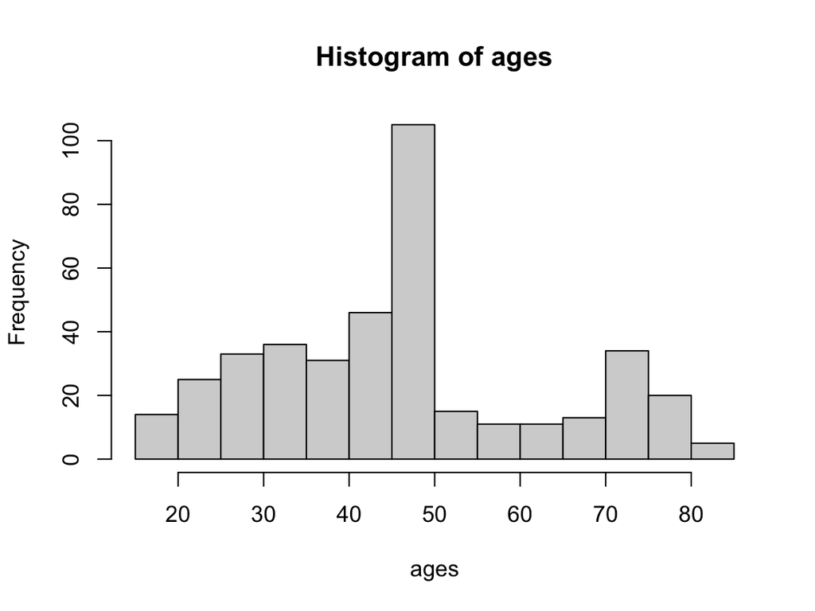

```r
hist(customers$age, main = "Histogram of ages", xlab = "ages")
```

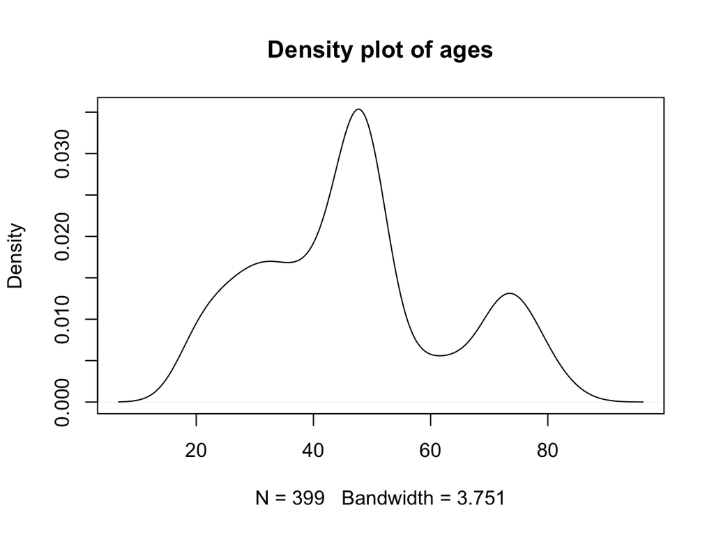

```r
plot(density(customers$age), main = "Density plot of ages")
```

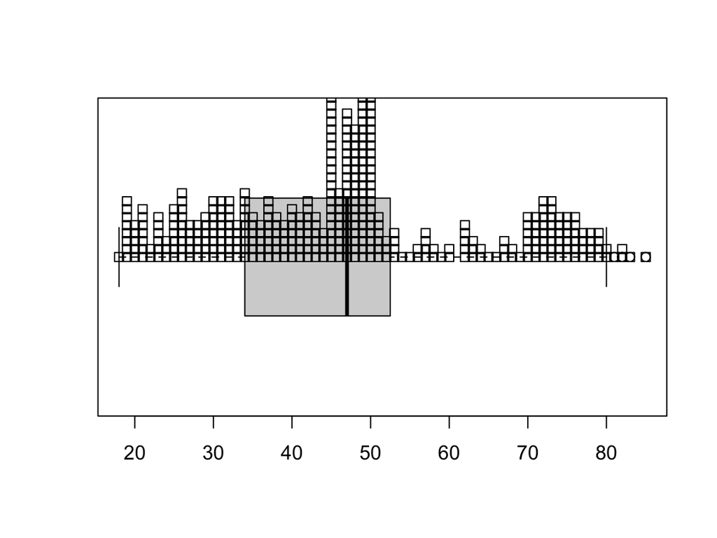

```r
boxplot(customers$age, horizontal = TRUE)
stripchart(customers$age, method = "stack", add = TRUE)
```